**Corso di :** Organizzazioni e Società Digitali - LAM a.a. 2020/21

**Esercizione di:** Martina Monti e Micol Dalle Fratte

# ANALISI PERCORSI DI STUDIO UNIVERSITARI

### Importo il primo dataframe

```python
import pandas as pd
coorti_per_genere = pd.read_csv("/Users/martinamonti/Desktop/punti extra/coorte-per-genere_all.csv",
                                usecols=['coorte','corso_descrizione','studenti', 'p_genere_m','p_genere_f'])
coorti_per_genere
```

|  | coorte | corso_descrizione | studenti | p_genere_m | p_genere_f |
| --- | --- | --- | --- | --- | --- |
| 0 | 2017/2018 | ARCHITETTURA | 90.0 | 0.478 | 0.522 |
| 1 | 2017/2018 | CHIMICA INDUSTRIALE | 79.0 | 0.658 | 0.342 |
| 2 | 2017/2018 | DIREZIONE AZIENDALE | 117.0 | 0.650 | 0.350 |
| 3 | 2017/2018 | ECONOMIA E PROFESSIONE | 62.0 | 0.629 | 0.371 |
| 4 | 2017/2018,0901,"FINANZA, INTERMEDIARI E MERCAT... | NaN | NaN | NaN | NaN |
| ... | ... | ... | ... | ... | ... |
| 630 | 2015/2016 | AUTOMATION ENGINEERING / INGEGNERIA DELL?AUTOM... | 59.0 | 0.847 | 0.153 |
| 631 | 2015/2016 | INGEGNERIA PER L'AMBIENTE E IL TERRITORIO | 85.0 | 0.612 | 0.388 |
| 632 | 2015/2016 | CIVIL ENGINEERING | 60.0 | 0.783 | 0.217 |
| 633 | 2015/2016 | INGEGNERIA CHIMICA E DI PROCESSO | 87.0 | 0.609 | 0.391 |
| 634 | 2015/2016 | BUSINESS AND ECONOMICS/ECONOMIA E GESTIONE DI ... | 148.0 | 0.507 | 0.493 |

635 rows × 5 columns

```python
#aggiungere nuova colonna 'prevalenza_genere' che mi mostri in modo più intuitivo la maggioranza di genere di ciascun corso

import numpy as np
coorti_per_genere['prevalenza_genere']= np.where(coorti_per_genere['p_genere_m']>coorti_per_genere['p_genere_f'], 'M', 'F' )
coorti_per_genere
```

|  | coorte | corso_descrizione | studenti | p_genere_m | p_genere_f | prevalenza_genere |
| --- | --- | --- | --- | --- | --- | --- |
| 0 | 2017/2018 | ARCHITETTURA | 90.0 | 0.478 | 0.522 | F |
| 1 | 2017/2018 | CHIMICA INDUSTRIALE | 79.0 | 0.658 | 0.342 | M |
| 2 | 2017/2018 | DIREZIONE AZIENDALE | 117.0 | 0.650 | 0.350 | M |
| 3 | 2017/2018 | ECONOMIA E PROFESSIONE | 62.0 | 0.629 | 0.371 | M |
| 4 | 2017/2018,0901,"FINANZA, INTERMEDIARI E MERCAT... | NaN | NaN | NaN | NaN | F |
| ... | ... | ... | ... | ... | ... | ... |
| 630 | 2015/2016 | AUTOMATION ENGINEERING / INGEGNERIA DELL?AUTOM... | 59.0 | 0.847 | 0.153 | M |
| 631 | 2015/2016 | INGEGNERIA PER L'AMBIENTE E IL TERRITORIO | 85.0 | 0.612 | 0.388 | M |
| 632 | 2015/2016 | CIVIL ENGINEERING | 60.0 | 0.783 | 0.217 | M |
| 633 | 2015/2016 | INGEGNERIA CHIMICA E DI PROCESSO | 87.0 | 0.609 | 0.391 | M |
| 634 | 2015/2016 | BUSINESS AND ECONOMICS/ECONOMIA E GESTIONE DI ... | 148.0 | 0.507 | 0.493 | M |

635 rows × 6 columns

# Descrizione dataframe

Distribuzione degli studenti che si iscrivono ai **Corsi di studio per genere**, sia in termini di valore assoluto che di percentuale.

I dati si riferiscono alle coorti (gruppo di studenti che iniziano nello stesso anno accademico la propria carriera universitaria) dal 2015/2016 al 2017/2018.

Le percentuali sono indicate come valori compresi tra 0 (equivalente a 0%) e 1 (100%).

**corso_descrizione**: Descrizione del corso di studi

**studenti**: Totale degli studenti della coorte

**p_genere_m**: % di studenti

**p_genere_f**: % di studentesse

### Importo secondo dataframe

```python
coorti_per_diploma = pd.read_csv("/Users/martinamonti/Desktop/punti extra/coorte-per-diploma_all.csv",
                                 usecols=['coorte','corso_descrizione','studenti', 'p_diploma_professionale','p_diploma_tecnico',
                                'p_diploma_magistrale','p_diploma_liceo','p_diploma_altroitaliano','p_diploma_estero','p_diploma_nondefinito'])
coorti_per_diploma
```

|  | coorte | corso_descrizione | studenti | p_diploma_professionale | p_diploma_tecnico | p_diploma_magistrale | p_diploma_liceo | p_diploma_altroitaliano | p_diploma_estero | p_diploma_nondefinito |
| --- | --- | --- | --- | --- | --- | --- | --- | --- | --- | --- |
| 0 | 2017/2018 | ARCHITETTURA | 90.0 | 0.011 | 0.400 | 0.033 | 0.344 | 0.200 | 0.011 | 0.000 |
| 1 | 2017/2018 | INGEGNERIA ELETTRONICA E TELECOMUNICAZIONI | 112.0 | 0.027 | 0.366 | 0.000 | 0.518 | 0.000 | 0.080 | 0.009 |
| 2 | 2017/2018 | INGEGNERIA ENERGETICA | 149.0 | 0.013 | 0.322 | 0.000 | 0.597 | 0.007 | 0.060 | 0.000 |
| 3 | 2017/2018 | INGEGNERIA GESTIONALE | 250.0 | 0.000 | 0.092 | 0.004 | 0.892 | 0.000 | 0.012 | 0.000 |
| 4 | 2017/2018 | INGEGNERIA INFORMATICA | 186.0 | 0.011 | 0.328 | 0.000 | 0.629 | 0.005 | 0.027 | 0.000 |
| ... | ... | ... | ... | ... | ... | ... | ... | ... | ... | ... |
| 309 | 2015/2016 | SCIENZE DELLA COMUNICAZIONE | 476.0 | 0.059 | 0.193 | 0.204 | 0.458 | 0.046 | 0.038 | 0.002 |
| 310 | 2015/2016 | INGEGNERIA CHIMICA E BIOCHIMICA | 132.0 | 0.008 | 0.189 | 0.000 | 0.750 | 0.008 | 0.015 | 0.030 |
| 311 | 2015/2016 | INGEGNERIA CIVILE | 105.0 | 0.010 | 0.362 | 0.010 | 0.552 | 0.000 | 0.057 | 0.010 |
| 312 | 2015/2016 | SVILUPPO E COOPERAZIONE INTERNAZIONALE | 130.0 | 0.069 | 0.177 | 0.146 | 0.562 | 0.015 | 0.015 | 0.015 |
| 313 | 2015/2016 | BUSINESS AND ECONOMICS/ECONOMIA E GESTIONE DI ... | 148.0 | 0.000 | 0.101 | 0.000 | 0.669 | 0.027 | 0.162 | 0.041 |

314 rows × 10 columns

# Descrizione dataframe

Distribuzione degli studenti che si iscrivono ai **Corsi di studio per diploma**, sia in termini di valore assoluto che di percentuale.

I dati si riferiscono alle coorti (gruppo di studenti che iniziano nello stesso anno accademico la propria carriera universitaria) dal 2015/2016 al 2017/2018, e ai corsi di Laurea o Laurea Magistrale a ciclo unico.

Le percentuali sono indicate come valori compresi tra 0 (equivalente a 0%) e 1 (100%).

**corso_descrizione**: Descrizione del corso di studi

**studenti**: Totale degli studenti della coorte

**p_diploma_professionale**: % diploma di Istituti Professionali

**p_diploma_tecnico**: % diploma di Istituti Tecnici

**p_diploma_magistrale**: % diploma di Istituti Magistrali e Licei Psico - Pedagogici

**p_diploma_liceo**: % diploma di Licei Scientifici, Classici e Linguistici

**p_diploma_altroitaliano**: % diploma di altri istituti italiani

**p_diploma_estero**: % diploma estero

**p_diploma_nondefinito**: % altro diploma non definito

```python
#merge
coorti= pd.merge(coorti_per_genere, coorti_per_diploma)
coorti
```

|  | coorte | corso_descrizione | studenti | p_genere_m | p_genere_f | prevalenza_genere | p_diploma_professionale | p_diploma_tecnico | p_diploma_magistrale | p_diploma_liceo | p_diploma_altroitaliano | p_diploma_estero | p_diploma_nondefinito |
| --- | --- | --- | --- | --- | --- | --- | --- | --- | --- | --- | --- | --- | --- |
| 0 | 2017/2018 | ARCHITETTURA | 90.0 | 0.478 | 0.522 | F | 0.011 | 0.400 | 0.033 | 0.344 | 0.200 | 0.011 | 0.000 |
| 1 | 2017/2018 | INGEGNERIA ELETTRONICA E TELECOMUNICAZIONI | 112.0 | 0.866 | 0.134 | M | 0.027 | 0.366 | 0.000 | 0.518 | 0.000 | 0.080 | 0.009 |
| 2 | 2017/2018 | INGEGNERIA ENERGETICA | 149.0 | 0.745 | 0.255 | M | 0.013 | 0.322 | 0.000 | 0.597 | 0.007 | 0.060 | 0.000 |
| 3 | 2017/2018 | INGEGNERIA GESTIONALE | 250.0 | 0.632 | 0.368 | M | 0.000 | 0.092 | 0.004 | 0.892 | 0.000 | 0.012 | 0.000 |
| 4 | 2017/2018 | INGEGNERIA INFORMATICA | 186.0 | 0.871 | 0.129 | M | 0.011 | 0.328 | 0.000 | 0.629 | 0.005 | 0.027 | 0.000 |
| ... | ... | ... | ... | ... | ... | ... | ... | ... | ... | ... | ... | ... | ... |
| 285 | 2015/2016 | SCIENZE DELLA COMUNICAZIONE | 476.0 | 0.345 | 0.655 | F | 0.059 | 0.193 | 0.204 | 0.458 | 0.046 | 0.038 | 0.002 |
| 286 | 2015/2016 | INGEGNERIA CHIMICA E BIOCHIMICA | 132.0 | 0.545 | 0.455 | M | 0.008 | 0.189 | 0.000 | 0.750 | 0.008 | 0.015 | 0.030 |
| 287 | 2015/2016 | INGEGNERIA CIVILE | 105.0 | 0.657 | 0.343 | M | 0.010 | 0.362 | 0.010 | 0.552 | 0.000 | 0.057 | 0.010 |
| 288 | 2015/2016 | SVILUPPO E COOPERAZIONE INTERNAZIONALE | 130.0 | 0.377 | 0.623 | F | 0.069 | 0.177 | 0.146 | 0.562 | 0.015 | 0.015 | 0.015 |
| 289 | 2015/2016 | BUSINESS AND ECONOMICS/ECONOMIA E GESTIONE DI ... | 148.0 | 0.507 | 0.493 | M | 0.000 | 0.101 | 0.000 | 0.669 | 0.027 | 0.162 | 0.041 |

290 rows × 13 columns

## Analisi missing data

```python
coorti.isnull().any() #non ci sono missing data
```

```
coorte                     False
corso_descrizione          False
studenti                   False
p_genere_m                 False
p_genere_f                 False
prevalenza_genere          False
p_diploma_professionale    False
p_diploma_tecnico          False
p_diploma_magistrale       False
p_diploma_liceo            False
p_diploma_altroitaliano    False
p_diploma_estero           False
p_diploma_nondefinito      False
dtype: bool
```

```python
#trasformo il nome del corso nel nuovo indice
coorti_= coorti.set_index('corso_descrizione')
```

# ANALISI COORTE 2017-2018

**SELEZIONO CORSI A PREVALENZA MASCHILE NELLA COORTE 2017-2018**

```python
coorti2017_18_M= coorti_.query("coorte == '2017/2018' & prevalenza_genere == 'M'")
coorti2017_18_M
```

| corso_descrizione | coorte | studenti | p_genere_m | p_genere_f | prevalenza_genere | p_diploma_professionale | p_diploma_tecnico | p_diploma_magistrale | p_diploma_liceo | p_diploma_altroitaliano | p_diploma_estero | p_diploma_nondefinito |
| --- | --- | --- | --- | --- | --- | --- | --- | --- | --- | --- | --- | --- |
| INGEGNERIA ELETTRONICA E TELECOMUNICAZIONI | 2017/2018 | 112.0 | 0.866 | 0.134 | M | 0.027 | 0.366 | 0.000 | 0.518 | 0.000 | 0.080 | 0.009 |
| INGEGNERIA ENERGETICA | 2017/2018 | 149.0 | 0.745 | 0.255 | M | 0.013 | 0.322 | 0.000 | 0.597 | 0.007 | 0.060 | 0.000 |
| INGEGNERIA GESTIONALE | 2017/2018 | 250.0 | 0.632 | 0.368 | M | 0.000 | 0.092 | 0.004 | 0.892 | 0.000 | 0.012 | 0.000 |
| INGEGNERIA INFORMATICA | 2017/2018 | 186.0 | 0.871 | 0.129 | M | 0.011 | 0.328 | 0.000 | 0.629 | 0.005 | 0.027 | 0.000 |
| INGEGNERIA MECCANICA | 2017/2018 | 181.0 | 0.901 | 0.099 | M | 0.000 | 0.160 | 0.000 | 0.807 | 0.000 | 0.033 | 0.000 |
| INGEGNERIA EDILE - ARCHITETTURA | 2017/2018 | 74.0 | 0.514 | 0.486 | M | 0.000 | 0.324 | 0.014 | 0.568 | 0.081 | 0.014 | 0.000 |
| INGEGNERIA BIOMEDICA | 2017/2018 | 125.0 | 0.528 | 0.472 | M | 0.008 | 0.112 | 0.016 | 0.784 | 0.000 | 0.072 | 0.008 |
| INGEGNERIA MECCANICA | 2017/2018 | 113.0 | 0.938 | 0.062 | M | 0.027 | 0.531 | 0.000 | 0.425 | 0.018 | 0.000 | 0.000 |
| STORIA | 2017/2018 | 212.0 | 0.726 | 0.274 | M | 0.042 | 0.123 | 0.184 | 0.533 | 0.071 | 0.047 | 0.000 |
| ASTRONOMIA | 2017/2018 | 69.0 | 0.696 | 0.304 | M | 0.000 | 0.130 | 0.014 | 0.812 | 0.043 | 0.000 | 0.000 |
| FISICA | 2017/2018 | 137.0 | 0.788 | 0.212 | M | 0.000 | 0.036 | 0.007 | 0.942 | 0.000 | 0.015 | 0.000 |
| INFORMATICA | 2017/2018 | 118.0 | 0.890 | 0.110 | M | 0.008 | 0.508 | 0.008 | 0.458 | 0.008 | 0.008 | 0.000 |
| MATEMATICA | 2017/2018 | 226.0 | 0.513 | 0.487 | M | 0.018 | 0.177 | 0.053 | 0.686 | 0.035 | 0.031 | 0.000 |
| SCIENZE AMBIENTALI | 2017/2018 | 66.0 | 0.515 | 0.485 | M | 0.106 | 0.394 | 0.106 | 0.303 | 0.030 | 0.061 | 0.000 |
| INFORMATICA PER IL MANAGEMENT | 2017/2018 | 96.0 | 0.719 | 0.281 | M | 0.052 | 0.490 | 0.010 | 0.385 | 0.010 | 0.052 | 0.000 |
| SCIENZE GEOLOGICHE | 2017/2018 | 31.0 | 0.613 | 0.387 | M | 0.032 | 0.323 | 0.032 | 0.516 | 0.065 | 0.032 | 0.000 |
| MANAGEMENT E MARKETING | 2017/2018 | 139.0 | 0.691 | 0.309 | M | 0.000 | 0.086 | 0.036 | 0.806 | 0.000 | 0.072 | 0.000 |
| DIETISTICA (ABILITANTE ALLA PROFESSIONE SANITARIA DI DIETISTA) | 2017/2018 | 7.0 | 0.571 | 0.429 | M | 0.143 | 0.286 | 0.000 | 0.571 | 0.000 | 0.000 | 0.000 |
| PODOLOGIA (ABILITANTE ALLA PROFESSIONE SANITARIA DI PODOLOGO) | 2017/2018 | 8.0 | 0.625 | 0.375 | M | 0.125 | 0.500 | 0.000 | 0.250 | 0.000 | 0.125 | 0.000 |
| SCIENZE DELLE ATTIVITA' MOTORIE E SPORTIVE | 2017/2018 | 176.0 | 0.756 | 0.244 | M | 0.017 | 0.182 | 0.068 | 0.716 | 0.011 | 0.006 | 0.000 |
| CHIMICA INDUSTRIALE | 2017/2018 | 98.0 | 0.694 | 0.306 | M | 0.000 | 0.296 | 0.020 | 0.633 | 0.010 | 0.031 | 0.010 |
| CHIMICA E TECNOLOGIE PER L'AMBIENTE E PER I MATERIALI | 2017/2018 | 29.0 | 0.621 | 0.379 | M | 0.034 | 0.379 | 0.034 | 0.448 | 0.000 | 0.103 | 0.000 |
| CHIMICA E TECNOLOGIE PER L'AMBIENTE E PER I MATERIALI | 2017/2018 | 32.0 | 0.594 | 0.406 | M | 0.000 | 0.500 | 0.094 | 0.344 | 0.000 | 0.063 | 0.000 |
| TECNOLOGIE AGRARIE | 2017/2018 | 122.0 | 0.795 | 0.205 | M | 0.025 | 0.434 | 0.025 | 0.459 | 0.016 | 0.041 | 0.000 |
| SCIENZE DEL TERRITORIO E DELL'AMBIENTE AGRO-FORESTALE | 2017/2018 | 39.0 | 0.692 | 0.308 | M | 0.077 | 0.385 | 0.051 | 0.410 | 0.026 | 0.051 | 0.000 |
| ECONOMIA E MARKETING NEL SISTEMA AGRO-INDUSTRIALE | 2017/2018 | 68.0 | 0.676 | 0.324 | M | 0.074 | 0.368 | 0.029 | 0.515 | 0.000 | 0.000 | 0.015 |
| VITICOLTURA ED ENOLOGIA | 2017/2018 | 54.0 | 0.611 | 0.389 | M | 0.074 | 0.593 | 0.074 | 0.204 | 0.019 | 0.037 | 0.000 |
| TECNOLOGIE ALIMENTARI | 2017/2018 | 84.0 | 0.548 | 0.452 | M | 0.143 | 0.405 | 0.036 | 0.321 | 0.036 | 0.060 | 0.000 |
| INGEGNERIA DELL'ENERGIA ELETTRICA | 2017/2018 | 96.0 | 0.854 | 0.146 | M | 0.031 | 0.563 | 0.021 | 0.354 | 0.000 | 0.031 | 0.000 |
| INGEGNERIA E SCIENZE INFORMATICHE | 2017/2018 | 184.0 | 0.848 | 0.152 | M | 0.033 | 0.587 | 0.000 | 0.380 | 0.000 | 0.000 | 0.000 |
| SCIENZE DELLE ATTIVITA' MOTORIE E SPORTIVE | 2017/2018 | 96.0 | 0.688 | 0.313 | M | 0.063 | 0.313 | 0.031 | 0.531 | 0.042 | 0.021 | 0.000 |
| INGEGNERIA ELETTRONICA PER L'ENERGIA E L'INFORMAZIONE | 2017/2018 | 56.0 | 0.911 | 0.089 | M | 0.054 | 0.589 | 0.000 | 0.339 | 0.018 | 0.000 | 0.000 |
| ECONOMICS AND FINANCE /ECONOMIA E FINANZA | 2017/2018 | 100.0 | 0.610 | 0.390 | M | 0.020 | 0.130 | 0.030 | 0.530 | 0.010 | 0.280 | 0.000 |
| ECONOMIA AZIENDALE | 2017/2018 | 180.0 | 0.639 | 0.361 | M | 0.000 | 0.167 | 0.033 | 0.733 | 0.006 | 0.061 | 0.000 |
| SCIENZE STATISTICHE | 2017/2018 | 114.0 | 0.579 | 0.421 | M | 0.018 | 0.377 | 0.026 | 0.482 | 0.026 | 0.070 | 0.000 |
| INGEGNERIA CHIMICA E BIOCHIMICA | 2017/2018 | 144.0 | 0.535 | 0.465 | M | 0.007 | 0.271 | 0.007 | 0.694 | 0.007 | 0.014 | 0.000 |
| INGEGNERIA CIVILE | 2017/2018 | 92.0 | 0.717 | 0.283 | M | 0.022 | 0.391 | 0.000 | 0.489 | 0.033 | 0.065 | 0.000 |
| INGEGNERIA PER L'AMBIENTE E IL TERRITORIO | 2017/2018 | 93.0 | 0.645 | 0.355 | M | 0.000 | 0.290 | 0.000 | 0.645 | 0.022 | 0.043 | 0.000 |
| INGEGNERIA EDILE | 2017/2018 | 32.0 | 0.563 | 0.438 | M | 0.031 | 0.594 | 0.031 | 0.281 | 0.000 | 0.031 | 0.031 |
| ECONOMIA E COMMERCIO | 2017/2018 | 351.0 | 0.504 | 0.496 | M | 0.048 | 0.573 | 0.031 | 0.299 | 0.011 | 0.034 | 0.003 |
| MEDICINE AND SURGERY | 2017/2018 | 48.0 | 0.521 | 0.479 | M | 0.000 | 0.042 | 0.000 | 0.438 | 0.000 | 0.521 | 0.000 |
| FILOSOFIA | 2017/2018 | 255.0 | 0.537 | 0.463 | M | 0.016 | 0.071 | 0.145 | 0.714 | 0.039 | 0.016 | 0.000 |
| INGEGNERIA DELL?AUTOMAZIONE | 2017/2018 | 146.0 | 0.890 | 0.110 | M | 0.007 | 0.349 | 0.000 | 0.610 | 0.000 | 0.034 | 0.000 |
| INGEGNERIA AEROSPAZIALE | 2017/2018 | 110.0 | 0.809 | 0.191 | M | 0.009 | 0.264 | 0.018 | 0.682 | 0.009 | 0.018 | 0.000 |

```python
max_maschile= pd.DataFrame(coorti2017_18_M, columns=['p_genere_m', 'p_genere_f'])
max_maschile

print("Corsi Max prevalenza maschile:   ",
      max_maschile.loc[(max_maschile['p_genere_f']==0)])     #non ci sono corsi composti completamente da maschi
print("\n")
print("Corsi Max prevalenza maschile:   ",     #trovo la percentuale massima di maschi
      np.max(max_maschile.p_genere_m))
print("\n")
print("Corsi Max prevalenza maschile:   ",
      max_maschile.loc[(max_maschile['p_genere_m']>=0.9)])   #trovo i corsi con la percentuale di maschi più alta
```

```
Corsi Max prevalenza maschile:    Empty DataFrame
Columns: [p_genere_m, p_genere_f]
Index: []


Corsi Max prevalenza maschile:    0.938


Corsi Max prevalenza maschile:                                                        p_genere_m  p_genere_f
corso_descrizione
INGEGNERIA MECCANICA                                     0.901       0.099
INGEGNERIA MECCANICA                                     0.938       0.062
INGEGNERIA ELETTRONICA PER L'ENERGIA E L'INFORM...       0.911       0.089
```

- Nella coorte 2017-2018 non ci sono corsi formati da tutti studenti maschi.
- Il massimo di percentuale di maschi è del 94% ed è raggiunto nel corso di INGEGNERIA MECCANICA, segue poi INGEGNERIA ELETTRONICA PER L'ENERGIA E L'INFORMAZIONE e un altra classe di INGEGNERIA MECCANICA.

**SELEZIONO CORSI A PREVALENZA FEMMINILE NELLA COORTE 2017-2018**

```python
coorti2017_18_F = coorti_.query("coorte == '2017/2018' & prevalenza_genere == 'F'")
coorti2017_18_F
```

| corso_descrizione | coorte | studenti | p_genere_m | p_genere_f | prevalenza_genere | p_diploma_professionale | p_diploma_tecnico | p_diploma_magistrale | p_diploma_liceo | p_diploma_altroitaliano | p_diploma_estero | p_diploma_nondefinito |
| --- | --- | --- | --- | --- | --- | --- | --- | --- | --- | --- | --- | --- |
| ARCHITETTURA | 2017/2018 | 90.0 | 0.478 | 0.522 | F | 0.011 | 0.400 | 0.033 | 0.344 | 0.200 | 0.011 | 0.000 |
| LINGUE E LETTERATURE STRANIERE | 2017/2018 | 385.0 | 0.223 | 0.777 | F | 0.026 | 0.094 | 0.073 | 0.764 | 0.013 | 0.031 | 0.000 |
| BIOTECNOLOGIE | 2017/2018 | 85.0 | 0.412 | 0.588 | F | 0.000 | 0.082 | 0.000 | 0.918 | 0.000 | 0.000 | 0.000 |
| CHIMICA E CHIMICA DEI MATERIALI | 2017/2018 | 111.0 | 0.432 | 0.568 | F | 0.009 | 0.279 | 0.009 | 0.676 | 0.018 | 0.000 | 0.009 |
| SCIENZE BIOLOGICHE | 2017/2018 | 149.0 | 0.248 | 0.752 | F | 0.000 | 0.027 | 0.013 | 0.946 | 0.000 | 0.007 | 0.007 |
| SCIENZE NATURALI | 2017/2018 | 57.0 | 0.474 | 0.526 | F | 0.070 | 0.246 | 0.000 | 0.632 | 0.035 | 0.018 | 0.000 |
| SERVIZIO SOCIALE | 2017/2018 | 87.0 | 0.126 | 0.874 | F | 0.092 | 0.184 | 0.402 | 0.264 | 0.034 | 0.023 | 0.000 |
| SCIENZE INTERNAZIONALI E DIPLOMATICHE | 2017/2018 | 366.0 | 0.366 | 0.634 | F | 0.014 | 0.167 | 0.085 | 0.683 | 0.003 | 0.049 | 0.000 |
| MEDIAZIONE LINGUISTICA INTERCULTURALE | 2017/2018 | 160.0 | 0.169 | 0.831 | F | 0.019 | 0.100 | 0.013 | 0.825 | 0.000 | 0.038 | 0.006 |
| DESIGN DEL PRODOTTO INDUSTRIALE | 2017/2018 | 80.0 | 0.500 | 0.500 | F | 0.013 | 0.175 | 0.000 | 0.738 | 0.063 | 0.013 | 0.000 |
| ODONTOIATRIA E PROTESI DENTARIA | 2017/2018 | 20.0 | 0.350 | 0.650 | F | 0.050 | 0.000 | 0.000 | 0.900 | 0.000 | 0.050 | 0.000 |
| CHIMICA E TECNOLOGIA FARMACEUTICHE | 2017/2018 | 100.0 | 0.310 | 0.690 | F | 0.010 | 0.100 | 0.040 | 0.850 | 0.000 | 0.000 | 0.000 |
| MEDICINA E CHIRURGIA | 2017/2018 | 229.0 | 0.428 | 0.572 | F | 0.000 | 0.017 | 0.000 | 0.939 | 0.009 | 0.035 | 0.000 |
| INFERMIERISTICA (ABILITANTE ALLA PROFESSIONE SANITARIA DI INFERMIERE) | 2017/2018 | 205.0 | 0.180 | 0.820 | F | 0.054 | 0.156 | 0.137 | 0.624 | 0.005 | 0.020 | 0.005 |
| INFERMIERISTICA (ABILITANTE ALLA PROFESSIONE SANITARIA DI INFERMIERE) | 2017/2018 | 110.0 | 0.182 | 0.818 | F | 0.182 | 0.327 | 0.200 | 0.173 | 0.082 | 0.027 | 0.009 |
| INFERMIERISTICA (ABILITANTE ALLA PROFESSIONE SANITARIA DI INFERMIERE) | 2017/2018 | 167.0 | 0.204 | 0.796 | F | 0.120 | 0.222 | 0.174 | 0.407 | 0.060 | 0.018 | 0.000 |
| FISIOTERAPIA (ABILITANTE ALLA PROFESSIONE SANITARIA DI FISIOTERAPISTA) | 2017/2018 | 22.0 | 0.273 | 0.727 | F | 0.000 | 0.045 | 0.091 | 0.864 | 0.000 | 0.000 | 0.000 |
| EDUCAZIONE PROFESSIONALE (ABILITANTE ALLA PROFESSIONE SANITARIA DI EDUCATORE PROFESSIONALE) | 2017/2018 | 29.0 | 0.276 | 0.724 | F | 0.103 | 0.103 | 0.379 | 0.310 | 0.069 | 0.034 | 0.000 |
| LOGOPEDIA (ABILITANTE ALLA PROFESSIONE SANITARIA DI LOGOPEDISTA) | 2017/2018 | 11.0 | 0.000 | 1.000 | F | 0.000 | 0.091 | 0.000 | 0.909 | 0.000 | 0.000 | 0.000 |
| IGIENE DENTALE (ABILITANTE ALLA PROFESSIONE SANITARIA DI IGIENISTA DENTALE) | 2017/2018 | 14.0 | 0.143 | 0.857 | F | 0.143 | 0.071 | 0.071 | 0.571 | 0.000 | 0.143 | 0.000 |
| TECNICHE DI NEUROFISIOPATOLOGIA (ABILITANTE ALLA PROFESSIONE SANITARIA DI TECNICO DI NEUROFISIOPATOLOGIA) | 2017/2018 | 5.0 | 0.000 | 1.000 | F | 0.000 | 0.000 | 0.200 | 0.800 | 0.000 | 0.000 | 0.000 |
| TECNICHE ORTOPEDICHE (ABILITANTE ALLA PROFESSIONE SANITARIA DI TECNICO ORTOPEDICO) | 2017/2018 | 8.0 | 0.250 | 0.750 | F | 0.000 | 0.000 | 0.000 | 1.000 | 0.000 | 0.000 | 0.000 |
| TECNICHE DI LABORATORIO BIOMEDICO (ABILITANTE ALLA PROFESSIONE SANITARIA DI TECNICO DI LABORATORIO BIOMEDICO) | 2017/2018 | 8.0 | 0.500 | 0.500 | F | 0.000 | 0.125 | 0.000 | 0.625 | 0.000 | 0.250 | 0.000 |
| TECNICHE DELLA PREVENZIONE NELL'AMBIENTE E NEI LUOGHI DI LAVORO (ABILITANTE ALLA PROFESSIONE SANITARIA DI TECNICO DELLA PREVENZIONE NELL'AMBIENTE E NEI LUOGHI DI LAVORO) | 2017/2018 | 16.0 | 0.438 | 0.563 | F | 0.063 | 0.500 | 0.188 | 0.250 | 0.000 | 0.000 | 0.000 |
| SOCIOLOGIA | 2017/2018 | 151.0 | 0.318 | 0.682 | F | 0.106 | 0.252 | 0.238 | 0.291 | 0.060 | 0.053 | 0.000 |
| SCIENZE FARMACEUTICHE APPLICATE | 2017/2018 | 49.0 | 0.184 | 0.816 | F | 0.082 | 0.388 | 0.143 | 0.347 | 0.020 | 0.020 | 0.000 |
| VERDE ORNAMENTALE E TUTELA DEL PAESAGGIO | 2017/2018 | 33.0 | 0.394 | 0.606 | F | 0.212 | 0.515 | 0.000 | 0.212 | 0.061 | 0.000 | 0.000 |
| SCIENZE DELLA FORMAZIONE PRIMARIA | 2017/2018 | 183.0 | 0.077 | 0.923 | F | 0.011 | 0.093 | 0.361 | 0.519 | 0.016 | 0.000 | 0.000 |
| CONSERVAZIONE E RESTAURO DEI BENI CULTURALI (ABILITANTE AI SENSI DEL D. LGS N. 42/2004) | 2017/2018 | 9.0 | 0.000 | 1.000 | F | 0.000 | 0.000 | 0.000 | 0.778 | 0.111 | 0.111 | 0.000 |
| MEDICINA VETERINARIA | 2017/2018 | 52.0 | 0.385 | 0.615 | F | 0.000 | 0.096 | 0.019 | 0.750 | 0.019 | 0.115 | 0.000 |
| CULTURE E TECNICHE DELLA MODA | 2017/2018 | 189.0 | 0.122 | 0.878 | F | 0.101 | 0.175 | 0.132 | 0.381 | 0.090 | 0.111 | 0.011 |
| SCIENZE E TECNICHE PSICOLOGICHE | 2017/2018 | 220.0 | 0.268 | 0.732 | F | 0.036 | 0.150 | 0.200 | 0.555 | 0.036 | 0.023 | 0.000 |
| EDUCATORE NEI SERVIZI PER L'INFANZIA | 2017/2018 | 228.0 | 0.031 | 0.969 | F | 0.149 | 0.175 | 0.482 | 0.132 | 0.048 | 0.013 | 0.000 |
| EDUCATORE SOCIALE E CULTURALE | 2017/2018 | 203.0 | 0.187 | 0.813 | F | 0.172 | 0.167 | 0.310 | 0.276 | 0.054 | 0.020 | 0.000 |
| EDUCATORE SOCIALE E CULTURALE | 2017/2018 | 112.0 | 0.196 | 0.804 | F | 0.295 | 0.179 | 0.313 | 0.170 | 0.045 | 0.000 | 0.000 |
| ACQUACOLTURA E IGIENE DELLE PRODUZIONI ITTICHE | 2017/2018 | 43.0 | 0.419 | 0.581 | F | 0.093 | 0.395 | 0.070 | 0.279 | 0.093 | 0.070 | 0.000 |
| ECONOMIA DEL TURISMO | 2017/2018 | 165.0 | 0.352 | 0.648 | F | 0.121 | 0.303 | 0.055 | 0.297 | 0.012 | 0.200 | 0.012 |
| ECONOMIA DELL'IMPRESA | 2017/2018 | 155.0 | 0.497 | 0.503 | F | 0.135 | 0.413 | 0.077 | 0.284 | 0.032 | 0.032 | 0.026 |
| BENI CULTURALI | 2017/2018 | 179.0 | 0.223 | 0.777 | F | 0.073 | 0.134 | 0.106 | 0.358 | 0.251 | 0.078 | 0.000 |
| LETTERE | 2017/2018 | 617.0 | 0.256 | 0.744 | F | 0.013 | 0.050 | 0.110 | 0.775 | 0.036 | 0.015 | 0.002 |
| ASSISTENZA SANITARIA (ABILITANTE ALLA PROFESSIONE SANITARIA DI ASSISTENTE SANITARIO) | 2017/2018 | 10.0 | 0.300 | 0.700 | F | 0.100 | 0.100 | 0.400 | 0.300 | 0.100 | 0.000 | 0.000 |
| PRODUZIONI ANIMALI | 2017/2018 | 77.0 | 0.390 | 0.610 | F | 0.039 | 0.364 | 0.078 | 0.468 | 0.052 | 0.000 | 0.000 |
| SCIENZE DELLA COMUNICAZIONE | 2017/2018 | 533.0 | 0.341 | 0.659 | F | 0.060 | 0.205 | 0.191 | 0.447 | 0.054 | 0.043 | 0.000 |
| SVILUPPO E COOPERAZIONE INTERNAZIONALE | 2017/2018 | 111.0 | 0.360 | 0.640 | F | 0.063 | 0.153 | 0.117 | 0.604 | 0.045 | 0.009 | 0.009 |
| BUSINESS AND ECONOMICS/ECONOMIA E GESTIONE DI IMPRESA | 2017/2018 | 138.0 | 0.420 | 0.580 | F | 0.007 | 0.138 | 0.014 | 0.594 | 0.007 | 0.225 | 0.014 |
| OSTETRICIA (ABILITANTE ALLA PROFESSIONE SANITARIA DI OSTETRICA/O) | 2017/2018 | 15.0 | 0.000 | 1.000 | F | 0.067 | 0.000 | 0.000 | 0.933 | 0.000 | 0.000 | 0.000 |
| GENOMICS | 2017/2018 | 33.0 | 0.303 | 0.697 | F | 0.000 | 0.152 | 0.000 | 0.788 | 0.000 | 0.061 | 0.000 |
| FARMACIA | 2017/2018 | 150.0 | 0.253 | 0.747 | F | 0.000 | 0.080 | 0.053 | 0.827 | 0.007 | 0.033 | 0.000 |
| FARMACIA | 2017/2018 | 77.0 | 0.221 | 0.779 | F | 0.013 | 0.208 | 0.078 | 0.649 | 0.013 | 0.039 | 0.000 |
| CONSULENTE DEL LAVORO E DELLE RELAZIONI AZIENDALI | 2017/2018 | 217.0 | 0.364 | 0.636 | F | 0.106 | 0.378 | 0.138 | 0.258 | 0.018 | 0.078 | 0.023 |
| GIURISTA PER LE IMPRESE E PER LA PUBBLICA AMMINISTRAZIONE | 2017/2018 | 97.0 | 0.289 | 0.711 | F | 0.113 | 0.536 | 0.124 | 0.134 | 0.031 | 0.031 | 0.031 |
| GIURISPRUDENZA | 2017/2018 | 995.0 | 0.362 | 0.638 | F | 0.022 | 0.113 | 0.112 | 0.717 | 0.014 | 0.023 | 0.000 |
| GIURISPRUDENZA | 2017/2018 | 65.0 | 0.431 | 0.569 | F | 0.046 | 0.354 | 0.292 | 0.262 | 0.031 | 0.015 | 0.000 |

```python
max_femminile= pd.DataFrame(coorti2017_18_F, columns=['p_genere_m', 'p_genere_f'])

print("Max prevalenza femminile:   ",                              #trovo i corsi completamente femminili
      max_femminile.loc[(max_femminile['p_genere_m']==0)])
```

```
Max prevalenza femminile:                                                        p_genere_m  p_genere_f
corso_descrizione
LOGOPEDIA (ABILITANTE ALLA PROFESSIONE SANITARI...         0.0         1.0
TECNICHE DI NEUROFISIOPATOLOGIA (ABILITANTE ALL...         0.0         1.0
CONSERVAZIONE E RESTAURO DEI BENI CULTURALI (AB...         0.0         1.0
OSTETRICIA (ABILITANTE ALLA PROFESSIONE SANITAR...         0.0         1.0
```

- I corsi completamente formati da studentesse nella coorte 2017-2018 sono: LOGOPEDIA, TECNICHE DI NEUROFISIOPATOLOGIA, CONSERVAZIONE E RESTAURO DEI BENI CULTURALI e OSTETRICIA

# ANALISI GENERALE DALLA CORTE 2015 ALLA 2018

## Analizzo la distribuzione della provenienza in base al genere dal 2015 al 2018

**Utilizzo la funzione *groupby***

```python
coorti_genere = coorti_.groupby(['prevalenza_genere'])
coorti_genere.sum()
```

| prevalenza_genere | studenti | p_genere_m | p_genere_f | p_diploma_professionale | p_diploma_tecnico | p_diploma_magistrale | p_diploma_liceo | p_diploma_altroitaliano | p_diploma_estero | p_diploma_nondefinito |
| --- | --- | --- | --- | --- | --- | --- | --- | --- | --- | --- |
| F | 22853.0 | 42.442 | 113.56 | 8.926 | 28.561 | 16.960 | 88.697 | 5.912 | 5.914 | 1.030 |
| M | 15508.0 | 92.763 | 41.24 | 3.990 | 41.439 | 3.198 | 75.658 | 2.437 | 5.249 | 2.027 |

**Commento**:

- la maggioranza delle studentesse femmine proviene da un liceo
- la maggioranza di studenti maschi proviene da un liceo

Si può quindi affermare che, indipendentemente dal genere, la maggioranza degli studenti iscritti all'università provengono da un liceo, seguono poi gli istituti tecnici ed infine una quantità esigua proviene da istituti professionali.

## Analizzo quali sono i corsi con una prevalenza di genere femminile sopra il 60%

```python
coorti_F=coorti_.query("p_genere_f>0.60")
coorti_F
```

| corso_descrizione | coorte | studenti | p_genere_m | p_genere_f | prevalenza_genere | p_diploma_professionale | p_diploma_tecnico | p_diploma_magistrale | p_diploma_liceo | p_diploma_altroitaliano | p_diploma_estero | p_diploma_nondefinito |
| --- | --- | --- | --- | --- | --- | --- | --- | --- | --- | --- | --- | --- |
| LINGUE E LETTERATURE STRANIERE | 2017/2018 | 385.0 | 0.223 | 0.777 | F | 0.026 | 0.094 | 0.073 | 0.764 | 0.013 | 0.031 | 0.000 |
| SCIENZE BIOLOGICHE | 2017/2018 | 149.0 | 0.248 | 0.752 | F | 0.000 | 0.027 | 0.013 | 0.946 | 0.000 | 0.007 | 0.007 |
| SERVIZIO SOCIALE | 2017/2018 | 87.0 | 0.126 | 0.874 | F | 0.092 | 0.184 | 0.402 | 0.264 | 0.034 | 0.023 | 0.000 |
| SCIENZE INTERNAZIONALI E DIPLOMATICHE | 2017/2018 | 366.0 | 0.366 | 0.634 | F | 0.014 | 0.167 | 0.085 | 0.683 | 0.003 | 0.049 | 0.000 |
| MEDIAZIONE LINGUISTICA INTERCULTURALE | 2017/2018 | 160.0 | 0.169 | 0.831 | F | 0.019 | 0.100 | 0.013 | 0.825 | 0.000 | 0.038 | 0.006 |
| ... | ... | ... | ... | ... | ... | ... | ... | ... | ... | ... | ... | ... |
| BENI CULTURALI | 2015/2016 | 143.0 | 0.210 | 0.790 | F | 0.077 | 0.098 | 0.091 | 0.455 | 0.245 | 0.028 | 0.007 |
| LETTERE | 2015/2016 | 588.0 | 0.270 | 0.730 | F | 0.019 | 0.053 | 0.092 | 0.803 | 0.031 | 0.003 | 0.000 |
| ASSISTENZA SANITARIA (ABILITANTE ALLA PROFESSIONE SANITARIA DI ASSISTENTE SANITARIO) | 2015/2016 | 11.0 | 0.091 | 0.909 | F | 0.273 | 0.182 | 0.273 | 0.182 | 0.000 | 0.091 | 0.000 |
| SCIENZE DELLA COMUNICAZIONE | 2015/2016 | 476.0 | 0.345 | 0.655 | F | 0.059 | 0.193 | 0.204 | 0.458 | 0.046 | 0.038 | 0.002 |
| SVILUPPO E COOPERAZIONE INTERNAZIONALE | 2015/2016 | 130.0 | 0.377 | 0.623 | F | 0.069 | 0.177 | 0.146 | 0.562 | 0.015 | 0.015 | 0.015 |

122 rows × 12 columns

La tabella ottenuta mi permette di osservare tutti i corsi che hanno una prevalenza di genere femminile sopra il 60%, quindi abbastanza consistente. Posso notare che i corsi in cui prevale il genere femminile sono principalmente di tipo **umanistico-sociale** e di **professioni sanitarie**.

## Analizzo quali sono i corsi con una prevalenza di genere maschile sopra il 60%

```python
coorti_M=coorti_.query("p_genere_m>0.60")
coorti_M
```

| corso_descrizione | coorte | studenti | p_genere_m | p_genere_f | prevalenza_genere | p_diploma_professionale | p_diploma_tecnico | p_diploma_magistrale | p_diploma_liceo | p_diploma_altroitaliano | p_diploma_estero | p_diploma_nondefinito |
| --- | --- | --- | --- | --- | --- | --- | --- | --- | --- | --- | --- | --- |
| INGEGNERIA ELETTRONICA E TELECOMUNICAZIONI | 2017/2018 | 112.0 | 0.866 | 0.134 | M | 0.027 | 0.366 | 0.000 | 0.518 | 0.000 | 0.080 | 0.009 |
| INGEGNERIA ENERGETICA | 2017/2018 | 149.0 | 0.745 | 0.255 | M | 0.013 | 0.322 | 0.000 | 0.597 | 0.007 | 0.060 | 0.000 |
| INGEGNERIA GESTIONALE | 2017/2018 | 250.0 | 0.632 | 0.368 | M | 0.000 | 0.092 | 0.004 | 0.892 | 0.000 | 0.012 | 0.000 |
| INGEGNERIA INFORMATICA | 2017/2018 | 186.0 | 0.871 | 0.129 | M | 0.011 | 0.328 | 0.000 | 0.629 | 0.005 | 0.027 | 0.000 |
| INGEGNERIA MECCANICA | 2017/2018 | 181.0 | 0.901 | 0.099 | M | 0.000 | 0.160 | 0.000 | 0.807 | 0.000 | 0.033 | 0.000 |
| ... | ... | ... | ... | ... | ... | ... | ... | ... | ... | ... | ... | ... |
| INGEGNERIA ELETTRONICA PER L'ENERGIA E L'INFORMAZIONE | 2015/2016 | 28.0 | 0.893 | 0.107 | M | 0.036 | 0.750 | 0.000 | 0.143 | 0.071 | 0.000 | 0.000 |
| ACQUACOLTURA E IGIENE DELLE PRODUZIONI ITTICHE | 2015/2016 | 39.0 | 0.744 | 0.256 | M | 0.205 | 0.487 | 0.051 | 0.231 | 0.026 | 0.000 | 0.000 |
| ECONOMICS AND FINANCE /ECONOMIA E FINANZA | 2015/2016 | 96.0 | 0.688 | 0.313 | M | 0.010 | 0.188 | 0.000 | 0.583 | 0.010 | 0.177 | 0.031 |
| ECONOMIA AZIENDALE | 2015/2016 | 194.0 | 0.639 | 0.361 | M | 0.000 | 0.180 | 0.031 | 0.732 | 0.010 | 0.046 | 0.000 |
| INGEGNERIA CIVILE | 2015/2016 | 105.0 | 0.657 | 0.343 | M | 0.010 | 0.362 | 0.010 | 0.552 | 0.000 | 0.057 | 0.010 |

95 rows × 12 columns

La tabella ottenuta mi permette di osservare quali sono i corsi il cui il genere maschile è sopra il 60%. Analizzado i dati ottenuti dalla possiamo osservare che i corsi in cui prevale il genere maschile sono di tipo **economico ed ingegneristico**.

## Analisi distribuzione genere per provenienza

```python
coorti_1= coorti.groupby(['corso_descrizione','prevalenza_genere'])[["p_diploma_liceo","p_diploma_tecnico",
                                                                    'p_diploma_professionale']].mean()
coorti_1
```

| corso_descrizione | prevalenza_genere | p_diploma_liceo | p_diploma_tecnico | p_diploma_professionale |
| --- | --- | --- | --- | --- |
| ACQUACOLTURA E IGIENE DELLE PRODUZIONI ITTICHE | F | 0.279000 | 0.395000 | 0.093000 |
|  | M | 0.290000 | 0.465500 | 0.126500 |
| ARCHITETTURA | F | 0.433667 | 0.307667 | 0.007333 |
| ASSISTENZA SANITARIA (ABILITANTE ALLA PROFESSIONE SANITARIA DI ASSISTENTE SANITARIO) | F | 0.327333 | 0.094000 | 0.148000 |
| ASTRONOMIA | M | 0.753000 | 0.152667 | 0.009667 |
| ... | ... | ... | ... | ... |
| TECNOLOGIE ALIMENTARI | F | 0.414000 | 0.309500 | 0.121000 |
|  | M | 0.321000 | 0.405000 | 0.143000 |
| VERDE ORNAMENTALE E TUTELA DEL PAESAGGIO | F | 0.185500 | 0.485000 | 0.185500 |
|  | M | 0.288000 | 0.500000 | 0.077000 |
| VITICOLTURA ED ENOLOGIA | M | 0.287333 | 0.453667 | 0.077000 |

115 rows × 3 columns

Questa funzione di *groupby()* mi permette di creare una tabella con *due indici*:

- **corso_descrizione**
- **prevalenza_genere**. Visualizza la distribuzione, divisa per genere, della provenienza di scuola superiore per ogni corso di laurea.

# ANALISI GRAFICA

```python
#librerie grafiche
%matplotlib inline
import matplotlib.pyplot as plt
import seaborn as sns
sns.set(style="whitegrid")
```

## Analizzo la distribuzione di genere a seconda dei diversi diplomi

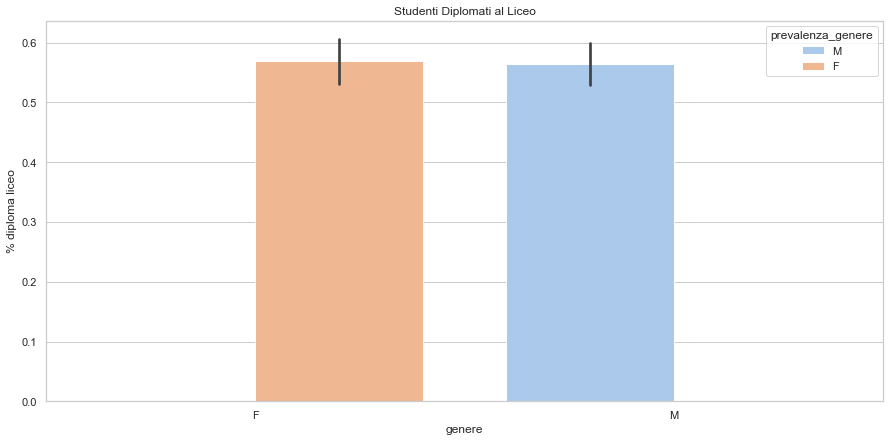

```python
#diploma liceo
fig, ax = plt.subplots(figsize=(15,7)) #per aumentare le dimensioni del grafico
sns.barplot(data=coorti, x='prevalenza_genere', y='p_diploma_liceo',
            hue="prevalenza_genere", hue_order=['M', 'F'], palette="pastel")
plt.xlabel("genere")
plt.ylabel("% diploma liceo")
plt.title("Studenti Diplomati al Liceo")
```

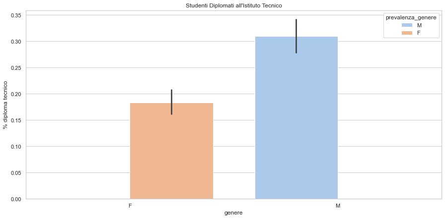

```python
#diploma istituto tecnico
fig, ax = plt.subplots(figsize=(15,7))
sns.barplot(data=coorti, x='prevalenza_genere', y='p_diploma_tecnico',
            hue="prevalenza_genere", hue_order=['M', 'F'], palette="pastel")
plt.xlabel("genere")
plt.ylabel("% diploma tecnico")
plt.title("Studenti Diplomati all'Istituto Tecnico")
```

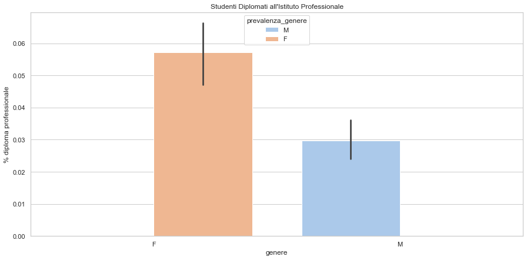

```python
#diploma istituto professionale
fig, ax = plt.subplots(figsize=(15,7))
sns.barplot(data=coorti, x='prevalenza_genere', y='p_diploma_professionale',
            hue="prevalenza_genere", hue_order=['M', 'F'], palette="pastel")
plt.xlabel("genere")
plt.ylabel("% diploma professionale")
plt.title("Studenti Diplomati all'Istituto Professionale")
```

- La percentuale di maschi e femmine diplomati al liceo è pressochè uguale, ed è superiore rispetto agli altri istituti
- Gli studenti universitari diplomati negli istituti tecnici sono di maggioranza maschi
- Gli studenti diplomati negli istituti professionali sono a maggioranza femmine, tuttavia la percentuale è molto bassa rispetti ai diplomati nei licei o istituti tecnici

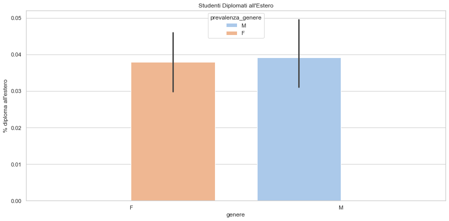

```python
#diploma all'estero
fig, ax = plt.subplots(figsize=(15,7))
sns.barplot(data=coorti, x='prevalenza_genere', y='p_diploma_estero',
            hue="prevalenza_genere", hue_order=['M','F'], palette="pastel")
plt.xlabel("genere")
plt.ylabel("% diploma all'estero")
plt.title("Studenti Diplomati all'Estero")
```

La percentuale di studenti diplomati all'estero è molto bassa e la maggioranza tra maschi e femmine è irrilevante.

## Analizzo la distribuzione di genere dei diplomati al liceo nel tempo

```python
coorti
```

|  | coorte | corso_descrizione | studenti | p_genere_m | p_genere_f | prevalenza_genere | p_diploma_professionale | p_diploma_tecnico | p_diploma_magistrale | p_diploma_liceo | p_diploma_altroitaliano | p_diploma_estero | p_diploma_nondefinito |
| --- | --- | --- | --- | --- | --- | --- | --- | --- | --- | --- | --- | --- | --- |
| 0 | 2017/2018 | ARCHITETTURA | 90.0 | 0.478 | 0.522 | F | 0.011 | 0.400 | 0.033 | 0.344 | 0.200 | 0.011 | 0.000 |
| 1 | 2017/2018 | INGEGNERIA ELETTRONICA E TELECOMUNICAZIONI | 112.0 | 0.866 | 0.134 | M | 0.027 | 0.366 | 0.000 | 0.518 | 0.000 | 0.080 | 0.009 |
| 2 | 2017/2018 | INGEGNERIA ENERGETICA | 149.0 | 0.745 | 0.255 | M | 0.013 | 0.322 | 0.000 | 0.597 | 0.007 | 0.060 | 0.000 |
| 3 | 2017/2018 | INGEGNERIA GESTIONALE | 250.0 | 0.632 | 0.368 | M | 0.000 | 0.092 | 0.004 | 0.892 | 0.000 | 0.012 | 0.000 |
| 4 | 2017/2018 | INGEGNERIA INFORMATICA | 186.0 | 0.871 | 0.129 | M | 0.011 | 0.328 | 0.000 | 0.629 | 0.005 | 0.027 | 0.000 |
| ... | ... | ... | ... | ... | ... | ... | ... | ... | ... | ... | ... | ... | ... |
| 285 | 2015/2016 | SCIENZE DELLA COMUNICAZIONE | 476.0 | 0.345 | 0.655 | F | 0.059 | 0.193 | 0.204 | 0.458 | 0.046 | 0.038 | 0.002 |
| 286 | 2015/2016 | INGEGNERIA CHIMICA E BIOCHIMICA | 132.0 | 0.545 | 0.455 | M | 0.008 | 0.189 | 0.000 | 0.750 | 0.008 | 0.015 | 0.030 |
| 287 | 2015/2016 | INGEGNERIA CIVILE | 105.0 | 0.657 | 0.343 | M | 0.010 | 0.362 | 0.010 | 0.552 | 0.000 | 0.057 | 0.010 |
| 288 | 2015/2016 | SVILUPPO E COOPERAZIONE INTERNAZIONALE | 130.0 | 0.377 | 0.623 | F | 0.069 | 0.177 | 0.146 | 0.562 | 0.015 | 0.015 | 0.015 |
| 289 | 2015/2016 | BUSINESS AND ECONOMICS/ECONOMIA E GESTIONE DI ... | 148.0 | 0.507 | 0.493 | M | 0.000 | 0.101 | 0.000 | 0.669 | 0.027 | 0.162 | 0.041 |

290 rows × 13 columns

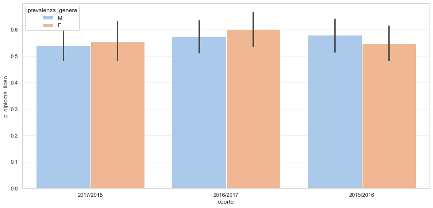

```python
#diploma liceo
fig, ax = plt.subplots(figsize=(15,7))
sns.barplot(y="p_diploma_liceo", x="coorte", hue="prevalenza_genere", hue_order=['M', 'F'], palette="pastel", data=coorti)
```

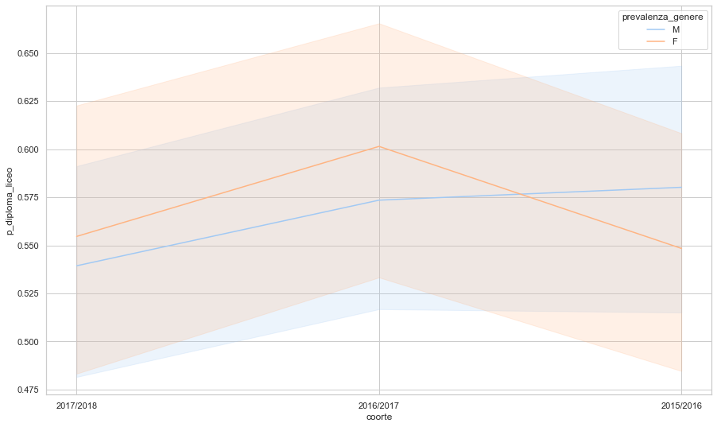

```python
fig, ax = plt.subplots(figsize=(15,9))
sns.lineplot(x="coorte", y="p_diploma_liceo",
            hue="prevalenza_genere",
            hue_order=['M', 'F'], palette="pastel",
           data=coorti)
```

Questi grafici mostrano la distribuzione di genere degli studenti diplomati al liceo delle tre coorti:

-> **si può concludere affermando che tra i diplomati al liceo non c'è grande differenza di genere**

## Analizzo la distribuzione di genere dei diplomati all'istituto tecnico nel tempo

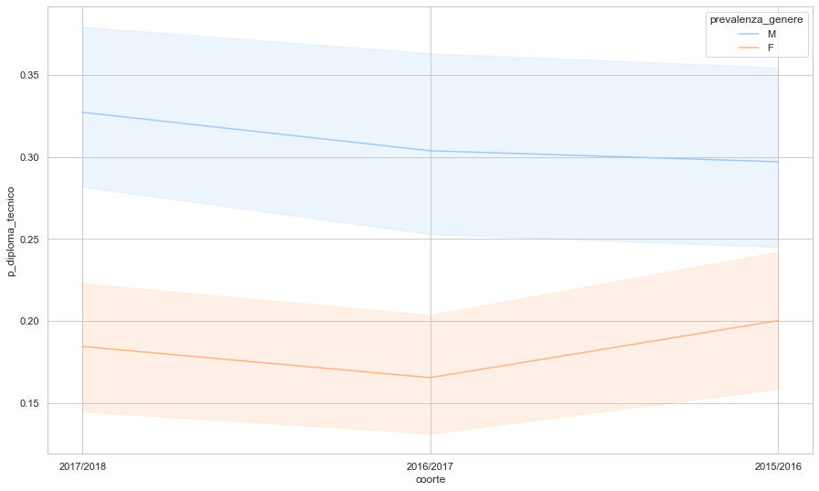

```python
#diploma istituti tecnici
fig, ax = plt.subplots(figsize=(15,9))
sns.lineplot(x="coorte", y="p_diploma_tecnico",
            hue="prevalenza_genere",
            hue_order=['M', 'F'], palette="pastel",
            data=coorti)
```

Questi grafici mostrano la distribuzione di genere degli studenti diplomati all'istituto tecnico delle tre coorti:

- **in tutte e tre le coorti la percentuale di maschi è superiore a quella delle femmine**

-> si può concludere affermando che tra i diplomati all'istituto tecnico prevalgono, in tutte e tre le coorti, gli studenti maschi

## Analizzo la distribuzione di genere dei diplomati all'istituto professionale nel tempo

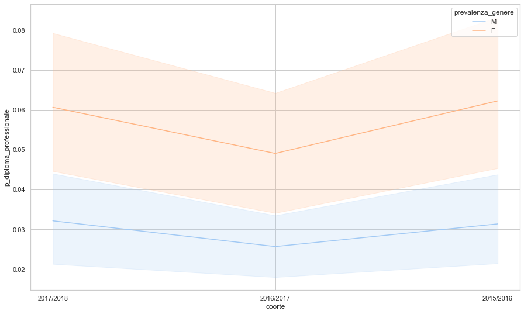

```python
#diploma istituti professionali
fig, ax = plt.subplots(figsize=(15,9))
sns.lineplot(x="coorte", y="p_diploma_professionale",
            hue="prevalenza_genere",
            hue_order=['M', 'F'], palette="pastel",
            data=coorti)
```

Questi grafici mostrano la distribuzione di genere degli studenti diplomati all'istituto professionale delle tre coorti:

- **in tutte e tre le coorti la percentuale di femmine è superiore a quella deli maschi**

-> si può concludere affermando che tra i diplomati all'istituto professionale prevalgono, in tutte e tre le coorti, le studentesse

## Analizzo la distribuzione di genere dei diplomati al liceo nel tempo

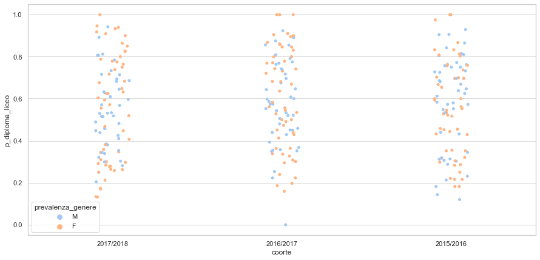

```python
fig, ax = plt.subplots(figsize=(15,7))
sns.stripplot(x="coorte", y="p_diploma_liceo", data=coorti,
              hue="prevalenza_genere", hue_order=['M', 'F'], palette="pastel",jitter=True)
```

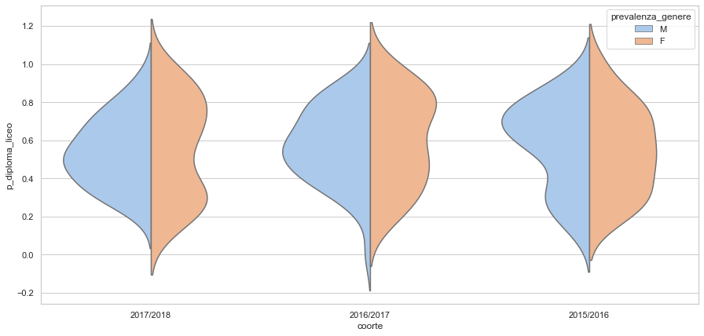

```python
fig, ax = plt.subplots(figsize=(15,7))
sns.violinplot(x="coorte", y="p_diploma_liceo",
            hue="prevalenza_genere",
            hue_order=['M', 'F'], palette="pastel", split=True, inner=None,
            data=coorti)
```

Questi grafici di tipo statistico (Violinplot) permettono di osservare come la percentuale degli studenti diplomati al liceo sia distribuita nelle tre diverse coorti e qual'è il genere prevalente in ognuna di esse.

- si può notare che la percentuale degli studenti diplomati al liceo, in relazione alle diverse coorti, risulta abbastanza omogenea.
- inoltre è possibile notare che **i diplomati al liceo rappresentano la maggioranza rispetto ai diplomati di istuti tecnici e professionali**

## Analizzo la distribuzione di genere dei diplomati all'istituto tecnico nel tempo

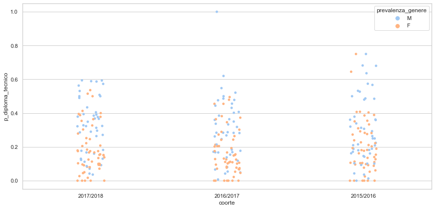

```python
fig, ax = plt.subplots(figsize=(15,7))
sns.stripplot(x="coorte", y="p_diploma_tecnico", data=coorti,
              hue="prevalenza_genere", hue_order=['M', 'F'], palette="pastel",jitter=True)
```

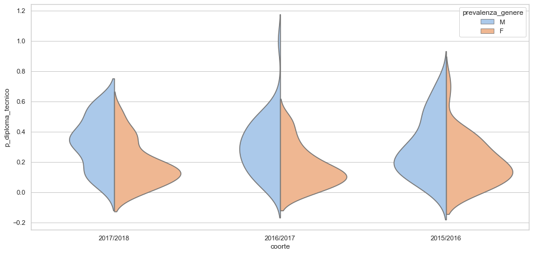

```python
fig, ax = plt.subplots(figsize=(15,7))
sns.violinplot(x="coorte", y="p_diploma_tecnico",
            hue="prevalenza_genere",
            hue_order=['M', 'F'], palette="pastel",split=True, inner=None,
            data=coorti)
```

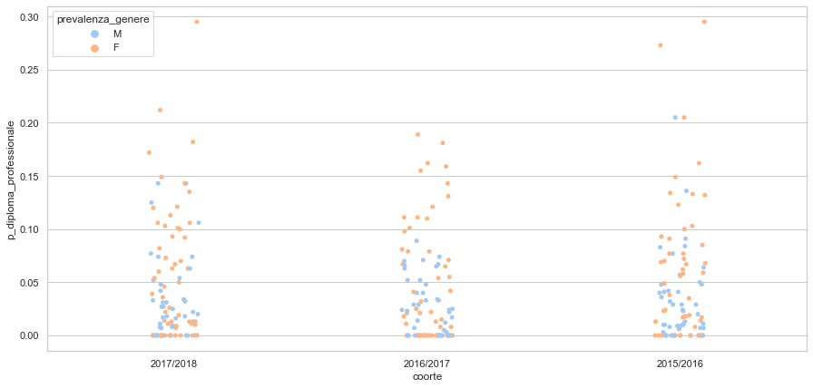

```python
fig, ax = plt.subplots(figsize=(15,7))
sns.stripplot(x="coorte", y="p_diploma_professionale", data=coorti,
              hue="prevalenza_genere", hue_order=['M', 'F'], palette="pastel",jitter=True)
```

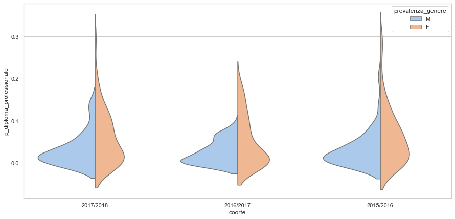

```python
fig, ax = plt.subplots(figsize=(15,7))
sns.violinplot(x="coorte", y="p_diploma_professionale",
            hue="prevalenza_genere",
            hue_order=['M', 'F'], palette="pastel",split=True,inner=None,
            data=coorti)
```

- Questo grafico permette di osservare che gli studenti **maschi** diplomati sono in percentuale molto bassa a differenza delle femmine che hanno percentuali più elevate in tutte e tre le corti.
- Anche se di poco la **coorte 2015/2016** presenta una percentuale più elevata di diplomati **totali** rispetto alle altre due.